# Used_car_in_egypt_exploratory_analysis_1762691138

## Part I - Used Car Market Dynamics in Egypt: An Exploratory Analysis

### Introduction

This exploration utilizes a cleaned and combined dataset focusing on the used car market in Egypt. The original data was gathered from two sources: a Kaggle dataset and web-scraped data from Sylndr [4]. The goal of this analysis is to investigate the factors influencing used car prices and identify market trends, focusing on brand dominance, geographic price variations, and model-specific pricing.

### Preliminary Wrangling

Load dataset and describe its properties through the questions below.

```python
import warnings
warnings.filterwarnings('ignore')
```

```python
# Importing the required libraries
import pandas as pd
import numpy as np
import matplotlib.pyplot as plt
import seaborn as sns

%matplotlib inline

# Set the seaborn style to 'whitegrid' for cleaner plots
sns.set_style('whitegrid')
# load data
car_df = pd.read_csv('merged_cars_data.csv')
car_df.head()
```

|  | brand | model | year | color | km | cc | transmission | city | price |
| --- | --- | --- | --- | --- | --- | --- | --- | --- | --- |
| 0 | Mercedes | C180 | 2015 | Blue | 107000 | 1600 | Automatic | Maadi | 1645000 |
| 1 | Citroen | C3 Aircross | 2020 | Orange | 128200 | 1200 | Automatic | Maadi | 795000 |
| 2 | BMW | 520i | 2019 | Black | 125100 | 2000 | Automatic | Maadi | 2030000 |
| 3 | Jeep | Cherokee | 2010 | Gray | 291870 | 3700 | Automatic | Maadi | 780000 |
| 4 | Fiat | Punto | 2017 | Dark Blue | 142760 | 1400 | Automatic | Maadi | 557140 |

```python
car_df.shape
```

```
(8912, 9)
```

```python
car_df.sample(6)
```

|  | brand | model | year | color | km | cc | transmission | city | price |
| --- | --- | --- | --- | --- | --- | --- | --- | --- | --- |
| 6859 | Byd | F3 | 2019 | Silver | 95000 | 1600 | Manual | Cairo | 190000 |
| 2576 | Toyota | Corolla | 2019 | Silver | 55000 | 1600 | Automatic | Tagamo3 - New Cairo | 635000 |
| 3797 | Mitsubishi | Xpander | 2022 | Gray | 32000 | 1500 | Automatic | Zamalek | 600000 |
| 4986 | Hyundai | I10 | 2016 | Red | 45000 | 1300 | Automatic | 6 October | 395000 |
| 6139 | Mercedes | E 300 | 2021 | Silver | 22000 | 2000 | Automatic | Cairo | 2350000 |
| 3419 | BMW | X4 | 2017 | Silver | 74000 | 3000 | Automatic | Tagamo3 - New Cairo | 1300000 |

```python
car_df.info()
```

```
<class 'pandas.core.frame.DataFrame'>
RangeIndex: 8912 entries, 0 to 8911
Data columns (total 9 columns):
 #   Column        Non-Null Count  Dtype
---  ------        --------------  -----
 0   brand         8912 non-null   object
 1   model         8912 non-null   object
 2   year          8912 non-null   int64
 3   color         8912 non-null   object
 4   km            8912 non-null   int64
 5   cc            8912 non-null   int64
 6   transmission  8912 non-null   object
 7   city          8912 non-null   object
 8   price         8912 non-null   int64
dtypes: int64(4), object(5)
memory usage: 626.8+ KB
```

##### What is the structure of my dataset?

The cleaned and combined dataset contains **8912 entries** across **9 columns** [3]. All columns are non-null and have appropriate data types, including four integers (`year`, `km`, `cc`, `price`) and five objects (`brand`, `model`, `color`, `transmission`, `city`).

##### What is/are the main feature(s) of interest in your dataset?

The main feature of interest is the **Price** of the vehicle in Egyptian Pounds (EGP), as the underlying problem statement focused on estimating fair market prices. Secondary features of interest include **Brand** and **Model**, necessary for determining market dominance.

##### What features in the dataset do you think will help support your investigation into your feature(s) of interest?

Features that will support the investigation into price include **Kilometers Driven (km)**, **Year** (age/depreciation), **Engine CC (cc)**, and **City** (location-based price variation).

### Univariate Exploration

In this section, investigate distributions of individual variables. (Requires at least 15 visualizations total across sections).

##### Question: What is the distribution of used car prices?

```python
car_df_mercedes = car_df.query('brand == "Mercedes"')
car_df_mercedes['price'].max(), car_df_mercedes['price'].min()
```

```
(np.int64(4800000), np.int64(40000))
```

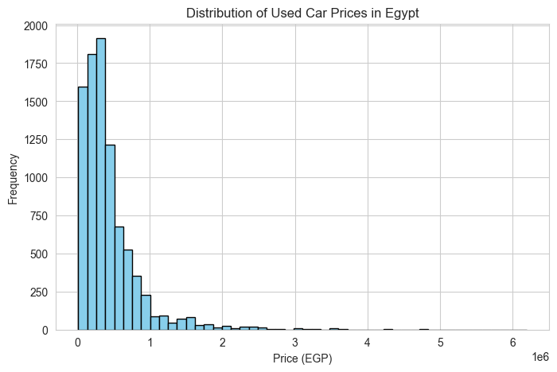

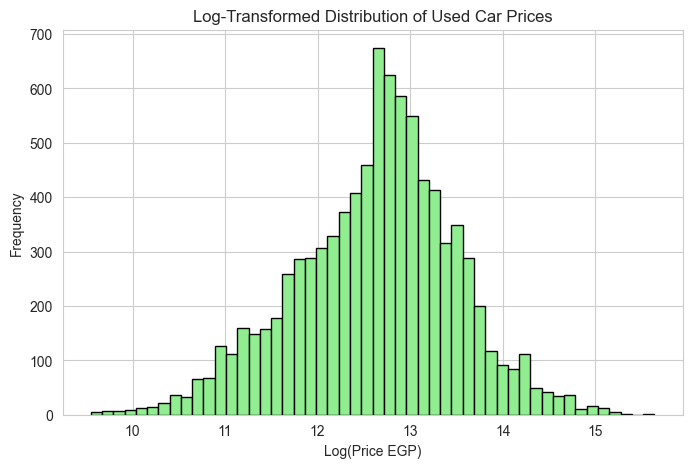

```python
# -   **Visualization Placeholder (Distribution of Price):** Histogram of the `price` column.
# Histogram of car prices
plt.figure(figsize=(8, 5))
plt.hist(car_df['price'], bins=50, color='skyblue', edgecolor='black')
plt.title('Distribution of Used Car Prices in Egypt')
plt.xlabel('Price (EGP)')
plt.ylabel('Frequency')
plt.show()

# Log-transformed histogram for normalization
plt.figure(figsize=(8, 5))
plt.hist(np.log(car_df['price']), bins=50, color='lightgreen', edgecolor='black')
plt.title('Log-Transformed Distribution of Used Car Prices')
plt.xlabel('Log(Price EGP)')
plt.ylabel('Frequency')
plt.show()
```

- **Observation:** This visualization would show the central tendency and spread of prices. Given the wide range and presence of luxury cars (e.g., Mercedes prices exceeding 3,000,000 EGP in the raw data), a right-skewed distribution is expected. Logarithmic transformation may be needed for normalization before correlation analysis.

##### Question: Which car brands are most dominant in the market?

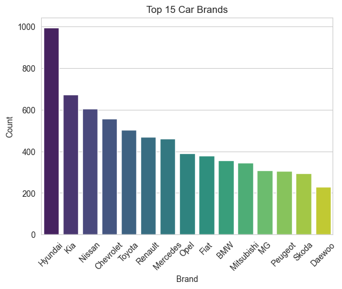

```python
top_brands = car_df['brand'].value_counts().head(15)
sns.countplot(data=car_df[car_df['brand'].isin(top_brands.index)],
              x='brand',
              order=top_brands.index,
              palette='viridis')
plt.title('Top 15 Car Brands')
plt.xlabel('Brand')
plt.ylabel('Count')
plt.xticks(rotation=45)
plt.show()
```

- **Visualization Placeholder (Top Brands):** Bar chart showing the counts of the top 15 values in the `brand` column.
- **Observation:** This plot is crucial for answering the first research question regarding dominant brands. The analysis should confirm the strong presence of Asian manufacturers.

##### Question: What is the distribution of Kilometers Driven (`km`)?

[figure not shown]

```python
ax = car_df.hist(column='km', bins=20, figsize=(12, 8))
plt.suptitle('Distribution of Kilometers Driven')
plt.xlabel('Kilometers Driven')
plt.ylabel('Frequency')

# Replace x-tick labels with bin range labels
xticks = []
for patch in ax[0][0].patches:
    start = int(patch.get_x())
    end = int(patch.get_x() + patch.get_width())
    xticks.append(f'{start}-{end}')
ax[0][0].set_xticklabels(xticks, rotation=45, ha='right')

plt.show()
```

- **Visualization Placeholder (Distribution of KM):** Histogram of the `km` column.
- **Observation:** This reveal that the market is dominated by low-mileage (newer) vehicles.

```python
# Visualization of Top-10 values per column

def visualize_top10(df: pd.DataFrame, exclude_cols: list = None, only: list = None, percentage: bool = False, top:bool = True) -> None:
    """
    Visualize the top-10 (or bottom-10) most frequent values for selected columns in a DataFrame.

    Parameters
    ----------
    df : pd.DataFrame
        The DataFrame to analyze.
    exclude_cols : list, optional
        Columns to exclude from visualization. Ignored if `only` is provided.
    only : list, optional
        If given, only these columns will be visualized.
    percentage : bool, default False
        If True, annotate bars with percentages; otherwise show raw counts.
    top : bool, default True
        If True, plot the 10 most frequent values; if False, plot the 10 least frequent.

    The function creates a vertically stacked set of count plots, one per selected column,
    each displaying the top (or bottom) 10 unique values for that column.
    """
    if only is not None:
        wanted_columns = [col for col in df.columns if col in only]
    else:
        wanted_columns = [col for col in df.columns if col not in (exclude_cols or [])]

    # Set up the matplotlib figure
    plt.figure(figsize=(15, len(wanted_columns) * 8))  # Adjust figure size

    # Loop through each categorical column
    for i, column in enumerate(wanted_columns):
        plt.subplot(len(wanted_columns), 1, i + 1)  # Create subplots

        # Get top 10
        if top:
            top_10 = df[column].value_counts().nlargest(10).index
            plt.title(f'Top {len(top_10)} for {column}')
        else:
            top_10 = df[column].value_counts().nsmallest(10).index
            plt.title(f'Bottom {len(top_10)} for {column}')
        ax = sns.countplot(data=df[df[column].isin(top_10)], x=column, order=top_10, palette='Set2')
        # Add count labels on top of bars
        total = len(df[df[column].isin(top_10)])
        for p in ax.patches:
            height = p.get_height()
            label = f'{float(height / total * 100):.2f}%' if percentage else f'{int(height)}'
            ax.annotate(label,
                        (p.get_x() + p.get_width() / 2., height),
                        ha='center', va='bottom')

        plt.xlabel(column)
        plt.xticks(rotation=45)
        plt.ylabel('Count')

    plt.tight_layout()  # Adjust spacing between plots
    plt.show()
```

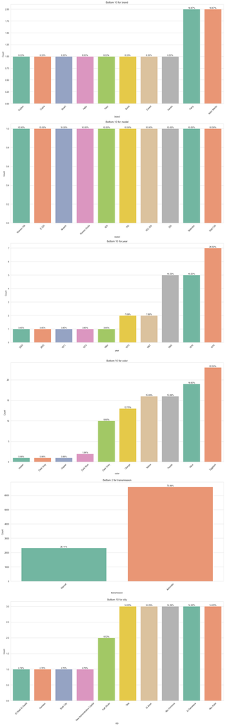

```python
# Bottom 10 our car dataframe

visualize_top10(car_df, percentage=True, top=False, exclude_cols=['price','cc','km'])
```

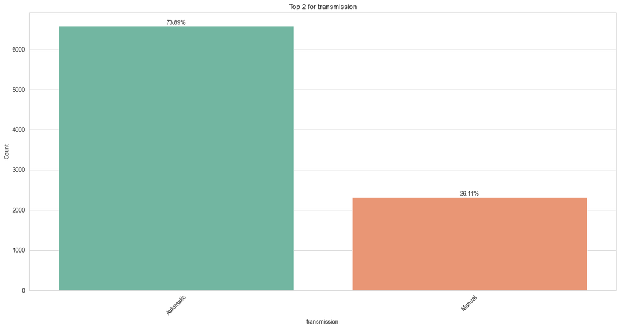

```python
# Automatic vs manual
visualize_top10(car_df, percentage=True, top=True, only=['transmission'])
```

### Bivariate Exploration

In this section, investigate relationships between pairs of variables.

##### Question: How does price vary across different cities?

```python
# Luxury and expensive used cars where they bought (Model 2020 and byound).

new_model = car_df[car_df['year']>=2020]
new_model_citis = (
    new_model
    .groupby('city')['price']
    .agg(['median','min','max'])
    .reset_index()
    .sort_values('median', ascending=False)
    .head(10)
)

new_model_citis
```

|  | city | median | min | max |
| --- | --- | --- | --- | --- |
| 28 | El Katameya | 2400000.0 | 1400000 | 2400000 |
| 86 | Zamalek | 1690000.0 | 430000 | 2400000 |
| 54 | Marsa Matrouh | 1200000.0 | 650000 | 1200000 |
| 35 | El Senbellawein | 900000.0 | 900000 | 900000 |
| 32 | El Minya | 895000.0 | 750000 | 1100000 |
| 80 | Tagamo3 - New Cairo | 757500.0 | 175000 | 3600000 |
| 44 | Ismailia | 750000.0 | 260000 | 1000000 |
| 56 | Minya Al Qamh | 732500.0 | 215000 | 1250000 |
| 52 | Madinaty | 730000.0 | 328000 | 2400000 |
| 51 | Maadi | 720000.0 | 215000 | 2550000 |

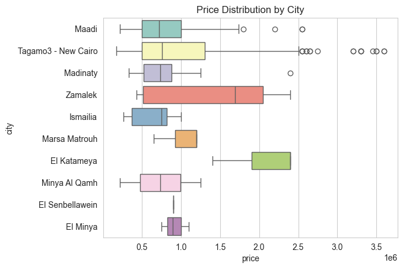

```python
sns.boxplot(y='city', x='price', data=new_model[new_model['city'].isin(new_model_citis['city'])], palette='Set3')
plt.title('Price Distribution by City')
# plt.xticks(rotation=90)
plt.show()
```

##### Question: How is the car price correlated with its manufacturing year?

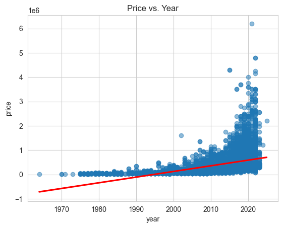

```python
sns.regplot(x='year', y='price', data=car_df, scatter_kws={'alpha':0.5}, line_kws={'color':'red'})
plt.title('Price vs. Year')
# plt.ylim(0, 8000000)
plt.show()
```

- **Visualization Placeholder (Price vs. Year):** Scatter plot of `price` against `year`.
- **Observation:** A positive correlation is expected (newer cars cost more).

##### Question: Does transmission type influence car price?

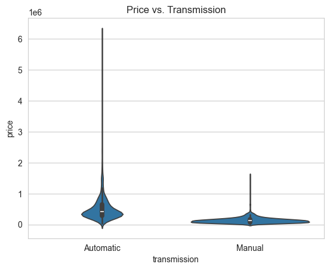

```python
sns.violinplot(x='transmission', y='price', data=car_df)
plt.title('Price vs. Transmission')
plt.show()
```

- **Visualization Placeholder (Price vs. Transmission):** Violin plots or box plots comparing the distribution of `price` for ‘Automatic’ versus ‘Manual’ transmission types.
- **Observation:**
  - Cars with automatic transmissions generally have much higher price variability, including several very expensive outliers that skew the distribution significantly upward.
  - Manual transmission cars mostly cluster at lower price ranges, with comparatively few expensive outliers and a tighter price spread around the median.
  - The widest section of the violin plot for automatic transmissions is at a higher price level compared to manual transmissions, highlighting where most listings or sales occur for each type.

### Multivariate Exploration

Create plots of three or more variables to investigate your data even further.

##### Question: How do Kilometers Driven and Price interact, and is this relationship moderated by Engine CC?

```python
car_df.cc.value_counts().head(15).index
```

```
Index([1600, 1500, 1400, 2000, 1300, 1200, 1800, 1000, 3000, 1100, 2500,  800,
       2400, 3500, 3800],
      dtype='int64', name='cc')
```

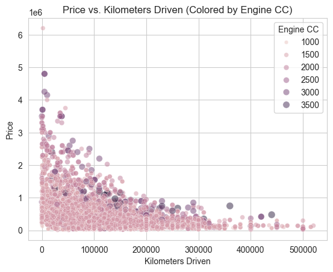

```python
data = car_df[car_df['cc'].isin(car_df.cc.value_counts().head(15).index)]
sns.scatterplot(data=data, x='km', y='price', hue='cc', size='cc', alpha=0.5)
plt.title('Price vs. Kilometers Driven (Colored by Engine CC)')
plt.xlabel('Kilometers Driven')
plt.ylabel('Price')
plt.legend(title='Engine CC')
plt.show()
```

- **Visualization Placeholder (Price, KM, and CC):** Scatter plot of `price` (Y-axis) versus `km` (X-axis), with point size or color intensity mapped to `Engine_CC`.
- **Observation:** Price decreases as kilometers increase. Mapping `cc` provides insight that high-performance (high CC) cars retain value better, especially at lower mileage.

##### Question: How do the top dominant models vary in price and mileage?

```python
frequent_models = car_df['model'].value_counts().head(5)
frequent_models
```

```
model
Sunny      436
Corolla    359
Cerato     212
Logan      191
Tipo       179
Name: count, dtype: int64
```

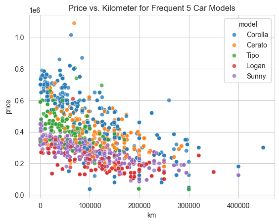

```python
data = car_df[car_df['model'].isin(frequent_models.index)]
sns.scatterplot(data=data, x='km', y='price', hue='model',alpha=0.75)
plt.title(f'Price vs. Kilometer for Frequent {frequent_models.count()} Car Models')
plt.show()
```

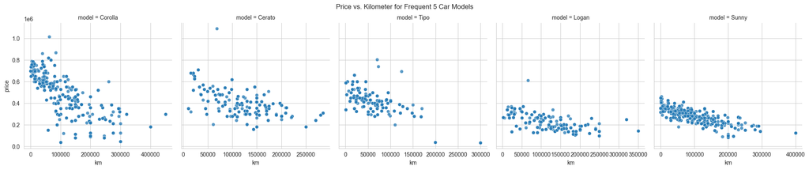

```python
import seaborn as sns
import matplotlib.pyplot as plt

data = car_df[car_df['model'].isin(frequent_models.index)]

# Create FacetGrid for each car model
g = sns.FacetGrid(
    data,
    col="model",
    col_wrap=5,              # Number of columns per row
    height=4,                # Size of each facet
    sharex=False,            # Optionally disable axis sharing
    sharey=True,
    palette="Set2"
)

g.map_dataframe(
    sns.scatterplot,
    x="km",
    y="price",
    alpha=0.75
)

g.fig.suptitle(f'Price vs. Kilometer for Frequent {frequent_models.count()} Car Models', y=1.03)
plt.show()
```

- **Visualization Placeholder (Top Models, Price, and KM):** Faceted scatter plots or overlaid box plots showing the relationship between `price` and `km`, separated by the top frequent 5 `model` entries (e.g., Nissan Sunny, Toyota Corolla, Kia Cerato).
- **Observation:**
  - There is a consistent negative correlation between price and kilometers driven for all five car models: as the number of kilometers increases, the price tends to decrease. This confirms the general expectation that higher mileage leads to lower resale values for used cars.
  - Spread of prices for each model is different at low mileage. Some models (e.g., Cerato, Corolla) show a broader range of prices when kilometers are low, possibly due to variations in year, trim, or condition. Others like Sunny appear more clustered and predictable.
  - A few outlier points (e.g., unusually expensive cars with higher mileage) are visible in some panels. These may represent rare trim levels, recent major maintenance, errors, or over estimations.

### Conclusions

The exploration successfully investigated market drivers like brand dominance, location-based pricing, and the relationship between age/mileage and price. **Nissan Sunny, Toyota Corolla, and Kia Cerato are confirmed as top models**. We also confirmed that location significantly impacts maximum pricing, with **Tagamo3 - New Cairo exhibiting the highest ceiling** [1]